# Analyse du succès reproducteurs des amphibiens - Maîtrise en biologie

Author

Claudie Bouffard

**IMPORTANT:** Les codes suivants ont été générés à l’aide de ChatGPT (GPT-6 par OpenAI, 2026) et le support d’Angélique Dupuch et Katrine Turgeon

## Glossaire

### **Liste d’espèces sélectionnées :**

- **Ambystoma :** Salamandres du genre *Ambystoma*. Les espèces présentes au Québec, la salamandre maculée (*A. maculatum*), la salamandre à points bleues (*A. laterale*) et/ou salamandres du complexe de Jerfferson (*A. jeffersonianum complex*), sont incluses dans cette étude. Celles-ci sont toutes des espèces concidérées comme dépendantes des étangs vernaux et qui partagent un cycle de vie similaires.
- **LISY :** Grenouille des bois (Lithobates sylvaticus). Espèce dépendante des étangs vernaux.
- **LICL :** Grenouille verte (*Lithobates clamitans*). Espèce associée aux habitats à canopées ouvertes et étangs permanents. Représente de la compétition/prédateur pour les espèces dépendantes des étangs vernaux.
- **PSCR :** Rainette cucifère (Pseudacris crucifer). Espèce versatile et non-prédatrice des espèces dépendantes des étangs vernaux.

### **Liste de type de traitements:**

- **PEH :** Plantation de peuplier hybrides sur monticule (entre 1 à 5 ans). Les arbres sont trop jeunes pour avoir un effet sur l’hydrologie par evapotranspiration. Canopée particulièrement ouverte car les arbres sont petits.
- **CPPTM :** Coupe avec Protection des Petites Tiges Marchandes. Similaire à la coupe totale mais certains jeunes arbres sont laissés sur place. Ceux-ci ont tendance à tomber avec le vent. Sur les terres de DOMTAR, cette pratique est majoritairement dans des peuplements résineux mais a été vu dans du feuillus
- **CJ :** Coupe de Jardinage. Coupe qui imite le régime de trouée naturel des forêts de feuillus matures. Cela n’empêche la dégradation du sol par les ornières de machinerie. La canopée reste fermée.
- **NAT:** Étangs vernaux sélectionnées dans des milieux protégés depuis au moins 70 ans. Celui-ci représente le contrôle pour mon étude.

## Est-ce la présence d’oeufs varie selon les types de traitements ?

### Ambysomes

1. **Préparation des données :**

   ```r
   library(readxl)
   library(dplyr)

   df <-read_excel("C:/Users/super/Université du Québec en Outaouais/CLAUDIE ÉTANGS VERNAUX - Documents/Stats/Reproduction/Oeufs/Data_base_oeufs.xlsx", sheet = 1)
   df$Traitement <- factor(df$Traitement)
   df$X <- as.numeric(scale(df$X))
   df$Y <- as.numeric(scale(df$Y)) #La standardisation permet au modèle de mieux fonctionner tout en conservant la relation spatiale parce que l'ordre de grandeur des x et y était originalement trop grand
   df$pres <- ifelse(df$Amby > 0, 1, 0) #création d'une colone de présence-abscence
   df$Traitement <- relevel(df$Traitement, ref = "PEH") #S'assurer que PEH est la référence
   df
   ```

   ```
   # A tibble: 56 × 16
      No_etang  Traitement Superficie_m2  Amby  ANAM anoure  DRVE  LICA  LICL  LISE
      <chr>     <fct>              <dbl> <dbl> <dbl>  <dbl> <dbl> <dbl> <dbl> <dbl>
    1 1WATCJ6   CJ                 16.5      1     0      0     0     0     0     0
    2 2WATCJ5   CJ                 43.5      3     0      0     0     0     0     0
    3 3WATCJ1   CJ                  2.66    16     0      0     0     0     0     0
    4 4WATCJ2   CJ                 38.1      6     0      0     0     0     0     0
    5 5WATCJ4   CJ                  7.2      3     0      0     0     0     0     0
    6 6WATCJ3   CJ                 24       10     0      0     0     0     0     0
    7 17WATPEH… PEH                 6.21     0     0      0     0     0     0     0
    8 7WATPEH2  PEH                26.7      0     0      0     0     0     0     0
    9 12WATPEH5 PEH                57.4      0     0      0     0     0     0     0
   10 8WATPEH1  PEH                13.4      0     0      0     0     0     0     0
   # ℹ 46 more rows
   # ℹ 6 more variables: LISY <dbl>, NOVI <dbl>, PSCR <dbl>, X <dbl>, Y <dbl>,
   #   pres <dbl>
   ```

   ```r
   df_oeufsA <- df
   ```

2. **Choix de l’analyse :**

   Ici on a présence/absence donc il faut un modèle binaire. Un GLM de la famille binaire serait intéressant. Par contre, on a un problème:

   ```r
   table(df$Traitement, df$pres)
   ```

   ```
            0  1
     PEH   14  2
     CJ     5 14
     CPPTM  9  6
     NAT    0  6
   ```

   On a une séparation complète pour NAT ! On doit ajouter une correction pour qu’un GLM fonctionne. Ainsi, on va ajouter brglmFit

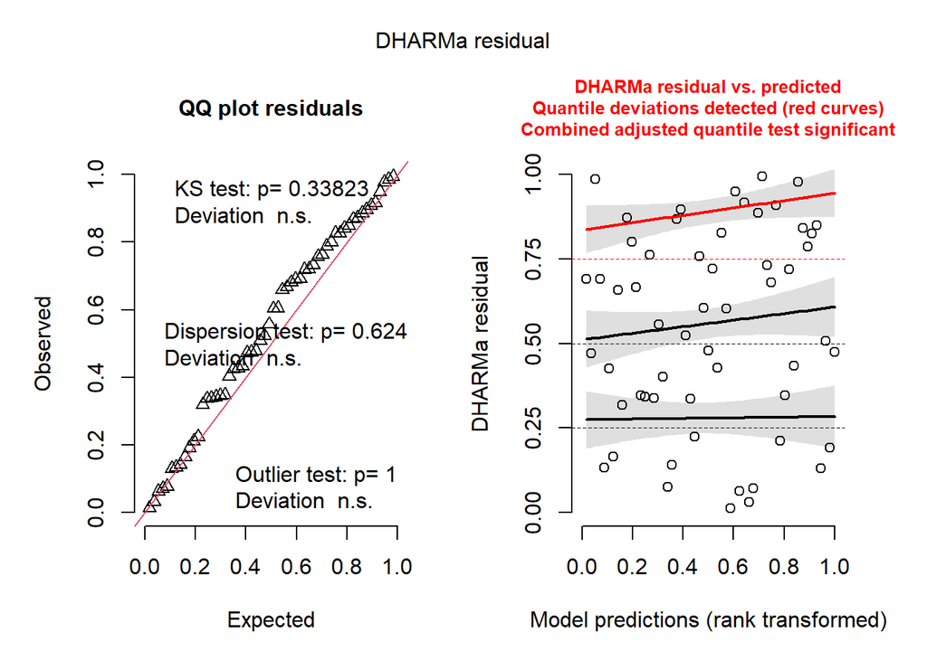

   ```r
   library(DHARMa)
   library(brglm2)
   mod2 <- glm(pres ~ Traitement + X + Y,family = binomial(link = "logit"),data = df,method = brglmFit)
   mod2A <- mod2
   res2 <- simulateResiduals(mod2)
   plot(res2) #res vs pred = première ligne rouge
   ```

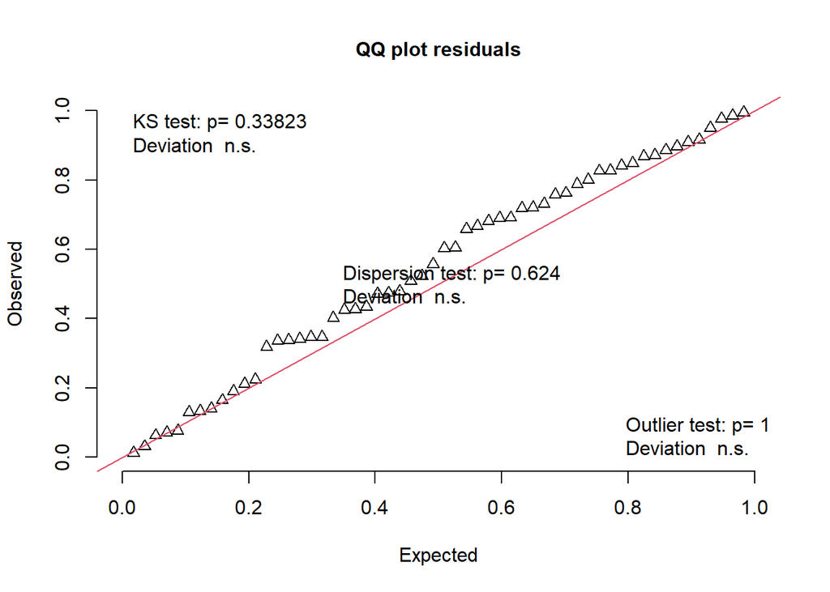

   ```
       Exact one-sample Kolmogorov-Smirnov test

   data:  simulationOutput$scaledResiduals
   D = 0.12289, p-value = 0.3382
   alternative hypothesis: two-sided
   ```

   ```r
   testUniformity(res2) #ok
   ```

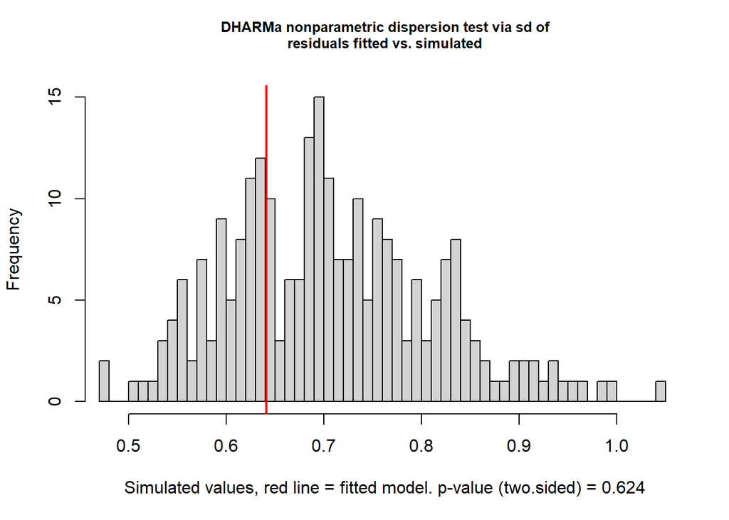

   ```
       DHARMa nonparametric dispersion test via sd of residuals fitted vs.
       simulated

   data:  simulationOutput
   dispersion = 0.90558, p-value = 0.624
   alternative hypothesis: two.sided
   ```

   ```r
   testDispersion(res2) #ok
   ```

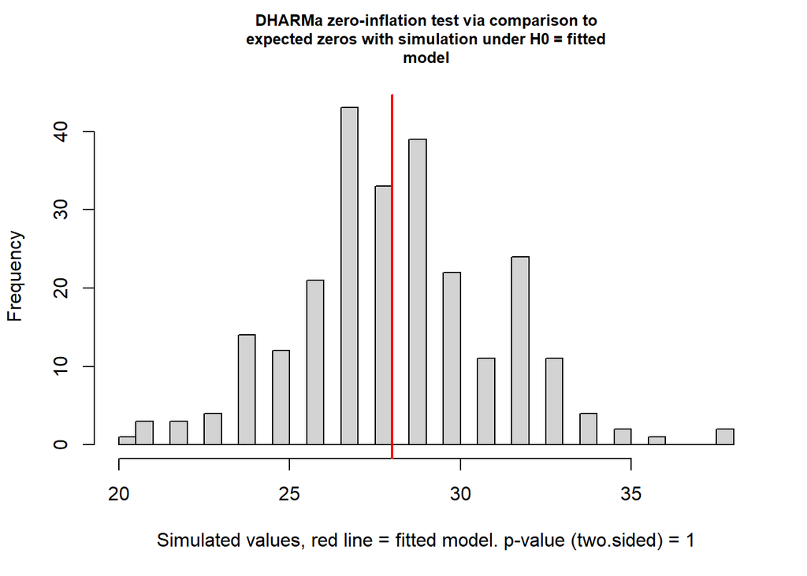

   ```
       DHARMa zero-inflation test via comparison to expected zeros with
       simulation under H0 = fitted model

   data:  simulationOutput
   ratioObsSim = 0.98745, p-value = 1
   alternative hypothesis: two.sided
   ```

   ```r
   testZeroInflation(res2) #ok
   ```

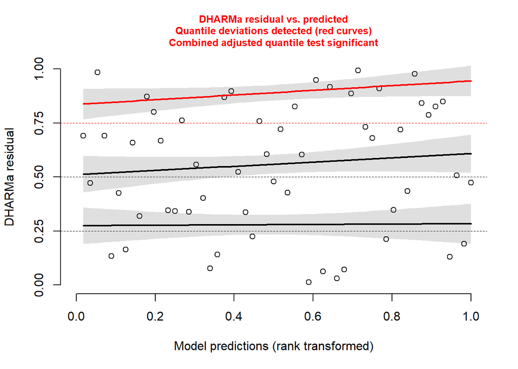

   ```
       Test for location of quantiles via qgam

   data:  res
   p-value = 0.0004702
   alternative hypothesis: both
   ```

   ```r
   testQuantiles(res2) #Pas ok
   ```

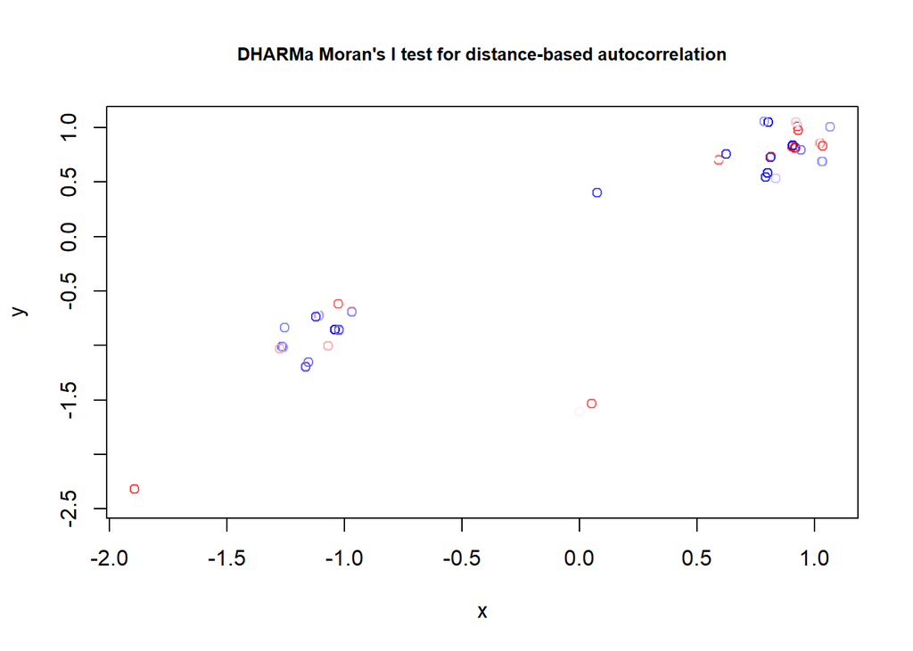

   ```
       DHARMa Moran's I test for distance-based autocorrelation

   data:  res2
   observed = 0.066510, expected = -0.018182, sd = 0.096187, p-value =
   0.3786
   alternative hypothesis: Distance-based autocorrelation
   ```

   ```r
   testSpatialAutocorrelation(res2,x = df$X,y = df$Y) #ok
   ```

   Ici le plot(res) n’est pas parfait. On voit aussi que testQuantiles est significatif. Toutefois, avec des n aussi bas, il sera difficile d’avoir un meilleur modèle. Ainsi, les prochains résultats devront être interprétés avec précaution.

   NOTE: J’ai essayé avec link=probit et cloglog, le testQuantiles s’améliore un peu mais les résultats du summary(mod) ne changent pas. Les AICc sont presque pareils. J’ai aussi essayé un modèle avec la correction logistf et les résultats sont très similaires au modèle choisi.
3. **Analyse :**

   ```r
   library(emmeans)
   summary(mod2)
   ```

   ```
   Call:
   glm(formula = pres ~ Traitement + X + Y, family = binomial(link = "logit"),
       data = df, method = brglmFit)

   Deviance Residuals:
        Min        1Q    Median        3Q       Max
   -1.65831  -0.75001  -0.06524   0.81976   2.14427

   Coefficients:
                   Estimate Std. Error z value Pr(>|z|)
   (Intercept)      -1.7282     0.7239  -2.387  0.01697 *
   TraitementCJ      2.7546     0.9050   3.044  0.00234 **
   TraitementCPPTM   1.4992     0.9085   1.650  0.09888 .
   TraitementNAT     3.4368     1.6177   2.125  0.03362 *
   X                 0.3900     1.2565   0.310  0.75626
   Y                -0.7425     1.3638  -0.544  0.58613
   ---
   Signif. codes:  0 '***' 0.001 '**' 0.01 '*' 0.05 '.' 0.1 ' ' 1

   (Dispersion parameter for binomial family taken to be 1)

       Null deviance: 77.632  on 55  degrees of freedom
   Residual deviance: 54.419  on 50  degrees of freedom
   AIC:  66.419

   Type of estimator: AS_mixed (mixed bias-reducing adjusted score equations)
   Number of Fisher Scoring iterations: 11
   ```

   ```r
   emm <- emmeans(mod2, ~ Traitement)
   emm
   ```

   ```
    Traitement emmean    SE  df asymp.LCL asymp.UCL
    PEH        -1.728 0.724 Inf -3.146946    -0.309
    CJ          1.026 0.523 Inf  0.000795     2.052
    CPPTM      -0.229 0.558 Inf -1.321785     0.864
    NAT         1.709 1.430 Inf -1.097972     4.515

   Results are given on the logit (not the response) scale.
   Confidence level used: 0.95
   ```

   ```r
   pairs(emm) #a=PEH, b=CJ, ab=CPPTM,NAT
   ```

   ```
    contrast    estimate    SE  df z.ratio p.value
    PEH - CJ      -2.755 0.905 Inf  -3.044  0.0125
    PEH - CPPTM   -1.499 0.908 Inf  -1.650  0.3504
    PEH - NAT     -3.437 1.620 Inf  -2.125  0.1453
    CJ - CPPTM     1.255 0.747 Inf   1.682  0.3334
    CJ - NAT      -0.682 1.540 Inf  -0.442  0.9711
    CPPTM - NAT   -1.938 1.580 Inf  -1.228  0.6089

   Results are given on the log odds ratio (not the response) scale.
   P value adjustment: tukey method for comparing a family of 4 estimates
   ```

   Sous l’optique de ma question de recherche qui se concentre sur la comparaison entre PEH et les autres traitements, les résultats du summary pourrait être plus pertinant que ceux de emmeans.
4. **Visualisation :**

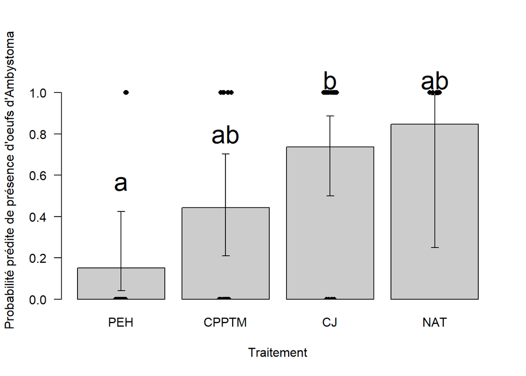

   ```r
   emm_prob <- emmeans(mod2, ~ Traitement, type = "response")
   res <- as.data.frame(emm_prob)
   ordre <- c("PEH", "CPPTM", "CJ", "NAT")
   res <- res[match(ordre, res$Traitement), ]
   moyennes <- res$prob
   inf <- res$asymp.LCL
   sup <- res$asymp.UCL

   barres <- barplot(moyennes,
                     names.arg = res$Traitement,
                     ylim = c(0, 1.15),
                     ylab = "Probabilité prédite de présence d'oeufs d'Ambystoma",
                     xlab = "Traitement",
                     col = "grey80",
                     border = "black",
                     las = 1)
   jit <- jitter(barres[match(df$Traitement, res$Traitement)],amount = 0.08)
   set.seed(123)
   points(jit, df$pres,
          pch = 16,
          cex = 0.8,
          col = "black")
   arrows(x0 = barres, y0 = inf,
          x1 = barres, y1 = sup,
          angle = 90, code = 3, length = 0.05)
   text(x = 0.7, y = 0.56, labels = "a", cex = 2) #PEH a
   text(x = 1.9, y = 0.8, labels = "ab", cex = 2) #CPPTM a
   text(x = 3.1, y = 1.06, labels = "b", cex = 2) #CJ b
   text(x = 4.3, y = 1.06, labels = "ab", cex = 2) #NAT b
   ```

   n PEH = 16 , n CPPTM = 15, n CJ = 19, NAT = 6

### LISY

1. **Préparation des données :**

   ```r
   df <-read_excel("C:/Users/super/Université du Québec en Outaouais/CLAUDIE ÉTANGS VERNAUX - Documents/Stats/Reproduction/Oeufs/Data_base_oeufs.xlsx", sheet = 1)
   df$Traitement <- factor(df$Traitement)
   df$X <- as.numeric(scale(df$X))
   df$Y <- as.numeric(scale(df$Y)) #La standardisation permet au modèle de mieux fonctionner tout en conservant la relation spatiale parce que l'ordre de grandeur des x et y était originalement trop grand
   df$pres <- ifelse(df$LISY > 0, 1, 0) #création d'une colone de présence-abscence
   df$Traitement <- relevel(df$Traitement, ref = "PEH") #S'assurer que PEH est la référence
   df
   ```

   ```
   # A tibble: 56 × 16
      No_etang  Traitement Superficie_m2  Amby  ANAM anoure  DRVE  LICA  LICL  LISE
      <chr>     <fct>              <dbl> <dbl> <dbl>  <dbl> <dbl> <dbl> <dbl> <dbl>
    1 1WATCJ6   CJ                 16.5      1     0      0     0     0     0     0
    2 2WATCJ5   CJ                 43.5      3     0      0     0     0     0     0
    3 3WATCJ1   CJ                  2.66    16     0      0     0     0     0     0
    4 4WATCJ2   CJ                 38.1      6     0      0     0     0     0     0
    5 5WATCJ4   CJ                  7.2      3     0      0     0     0     0     0
    6 6WATCJ3   CJ                 24       10     0      0     0     0     0     0
    7 17WATPEH… PEH                 6.21     0     0      0     0     0     0     0
    8 7WATPEH2  PEH                26.7      0     0      0     0     0     0     0
    9 12WATPEH5 PEH                57.4      0     0      0     0     0     0     0
   10 8WATPEH1  PEH                13.4      0     0      0     0     0     0     0
   # ℹ 46 more rows
   # ℹ 6 more variables: LISY <dbl>, NOVI <dbl>, PSCR <dbl>, X <dbl>, Y <dbl>,
   #   pres <dbl>
   ```

   ```r
   df_oeufsL <- df
   ```

2. **Choix de l’analyse :**

   ```r
   table(df$Traitement, df$pres)
   ```

   ```
            0  1
     PEH    0 16
     CJ     6 13
     CPPTM  0 15
     NAT    3  3
   ```

   Encore une fois, un GLM binaire serait intéressant. Mais, ici on a de la séparation, va falloir aussi corriger le modèle avec brglmFit

   ```
   qu = 0.75, log(sigma) = -2.909332 : outer Newton did not converge fully.
   ```

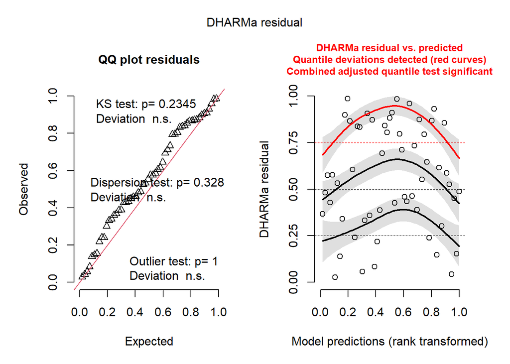

   ```r
   mod1 <- glm(pres ~ Traitement + X + Y,family = binomial(link = "logit"),data = df,method=brglmFit)
   mod1LO <- mod1
   res <- simulateResiduals(mod1)
   plot(res) #res vs pred = première ligne rouge
   ```

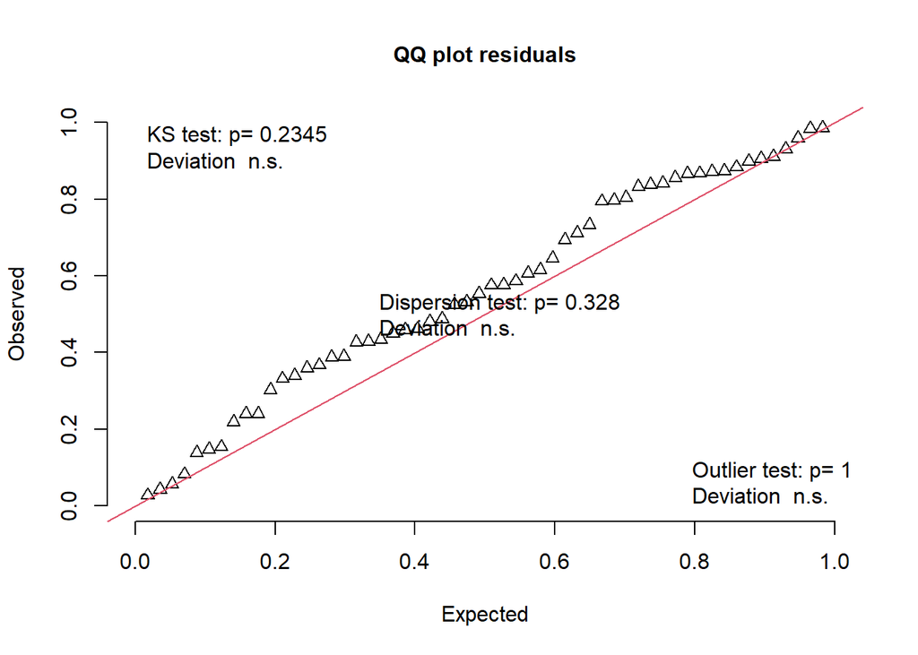

   ```
       Exact one-sample Kolmogorov-Smirnov test

   data:  simulationOutput$scaledResiduals
   D = 0.13533, p-value = 0.2345
   alternative hypothesis: two-sided
   ```

   ```r
   testUniformity(res) #ok
   ```

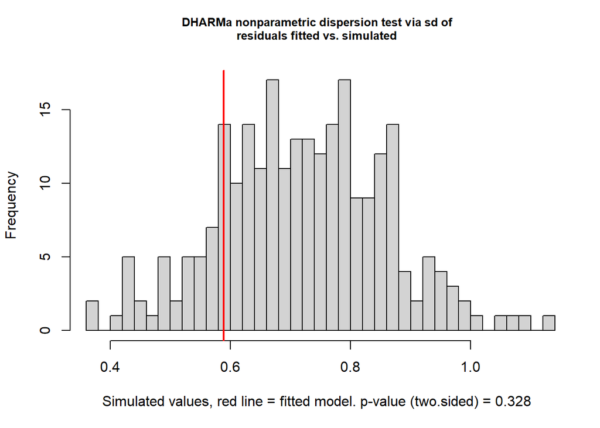

   ```
       DHARMa nonparametric dispersion test via sd of residuals fitted vs.
       simulated

   data:  simulationOutput
   dispersion = 0.81759, p-value = 0.328
   alternative hypothesis: two.sided
   ```

   ```r
   testDispersion(res) #ok
   ```

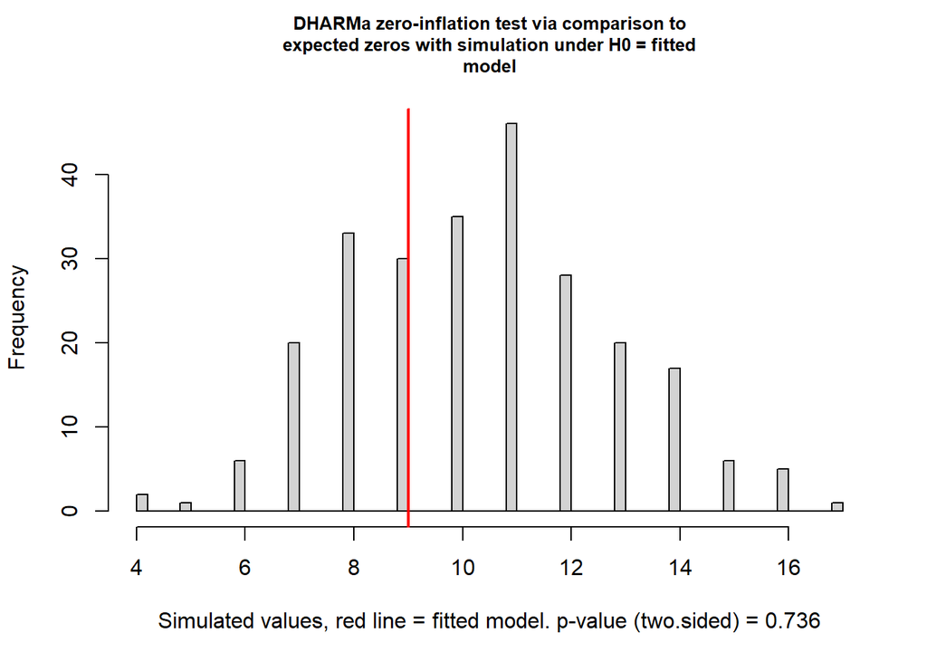

   ```
       DHARMa zero-inflation test via comparison to expected zeros with
       simulation under H0 = fitted model

   data:  simulationOutput
   ratioObsSim = 0.86538, p-value = 0.736
   alternative hypothesis: two.sided
   ```

   ```r
   testZeroInflation(res) #ok
   ```

   ```
   qu = 0.75, log(sigma) = -2.909332 : outer Newton did not converge fully.
   ```

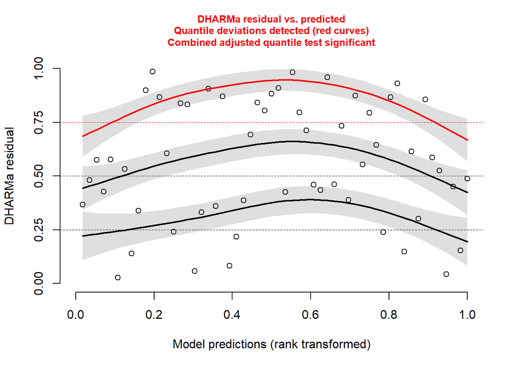

   ```
       Test for location of quantiles via qgam

   data:  res
   p-value = 0.00896
   alternative hypothesis: both
   ```

   ```r
   testQuantiles(res) #Pas bon pentoute
   ```

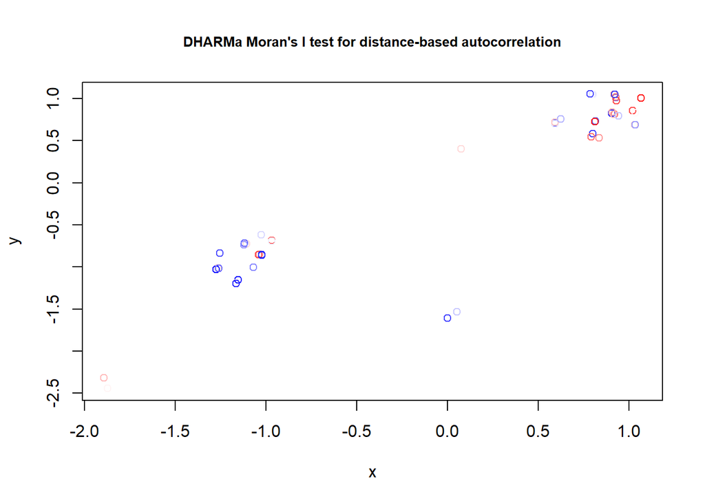

   ```
       DHARMa Moran's I test for distance-based autocorrelation

   data:  res
   observed = -0.022409, expected = -0.018182, sd = 0.096097, p-value =
   0.9649
   alternative hypothesis: Distance-based autocorrelation
   ```

   ```r
   testSpatialAutocorrelation(res,x = df$X,y = df$Y) #ok
   ```

   ```r
   mod1$converged
   ```

   ```
   [1] TRUE
   ```

   Le modèle ressemble à ce qu’on a dans l’analyse des ambysotme. Ici aussi, ça sera difficile d’avoir mieux. Donc on fera attention lors des interprétations.
3. **Analyse :**

   ```r
   summary(mod1)
   ```

   ```
   Call:
   glm(formula = pres ~ Traitement + X + Y, family = binomial(link = "logit"),
       data = df, method = brglmFit)

   Deviance Residuals:
       Min       1Q   Median       3Q      Max
   -1.7369   0.1762   0.2833   0.6654   1.2406

   Coefficients:
                   Estimate Std. Error z value Pr(>|z|)
   (Intercept)       3.8399     1.4914   2.575   0.0100 *
   TraitementCJ     -3.1691     1.5768  -2.010   0.0445 *
   TraitementCPPTM  -0.4197     2.0609  -0.204   0.8386
   TraitementNAT    -3.8497     1.8362  -2.097   0.0360 *
   X                 1.1229     0.9916   1.132   0.2575
   Y                -0.5547     1.0311  -0.538   0.5906
   ---
   Signif. codes:  0 '***' 0.001 '**' 0.01 '*' 0.05 '.' 0.1 ' ' 1

   (Dispersion parameter for binomial family taken to be 1)

       Null deviance: 49.390  on 55  degrees of freedom
   Residual deviance: 30.923  on 50  degrees of freedom
   AIC:  42.923

   Type of estimator: AS_mixed (mixed bias-reducing adjusted score equations)
   Number of Fisher Scoring iterations: 13
   ```

   ```r
   emm1 <- emmeans(mod1, ~ Traitement)
   emm1
   ```

   ```
    Traitement   emmean    SE  df asymp.LCL asymp.UCL
    PEH         3.83992 1.490 Inf     0.917      6.76
    CJ          0.67085 0.514 Inf    -0.336      1.68
    CPPTM       3.42019 1.450 Inf     0.569      6.27
    NAT        -0.00976 1.090 Inf    -2.155      2.14

   Results are given on the logit (not the response) scale.
   Confidence level used: 0.95
   ```

   ```r
   pairs(emm1)
   ```

   ```
    contrast    estimate   SE  df z.ratio p.value
    PEH - CJ       3.169 1.58 Inf   2.010  0.1843
    PEH - CPPTM    0.420 2.06 Inf   0.204  0.9970
    PEH - NAT      3.850 1.84 Inf   2.097  0.1542
    CJ - CPPTM    -2.749 1.54 Inf  -1.785  0.2803
    CJ - NAT       0.681 1.24 Inf   0.550  0.9465
    CPPTM - NAT    3.430 1.84 Inf   1.861  0.2452

   Results are given on the log odds ratio (not the response) scale.
   P value adjustment: tukey method for comparing a family of 4 estimates
   ```

   Encore une fois, dans la perspective du questionnement de ma recherche, les résultats du summary est intéressant. Selon le summary, PEH serait significativement différent du CJ et NAT.  
   Avec la correction de Tukey dans emmeans, rien n’est significatif
4. **Visualisation :**

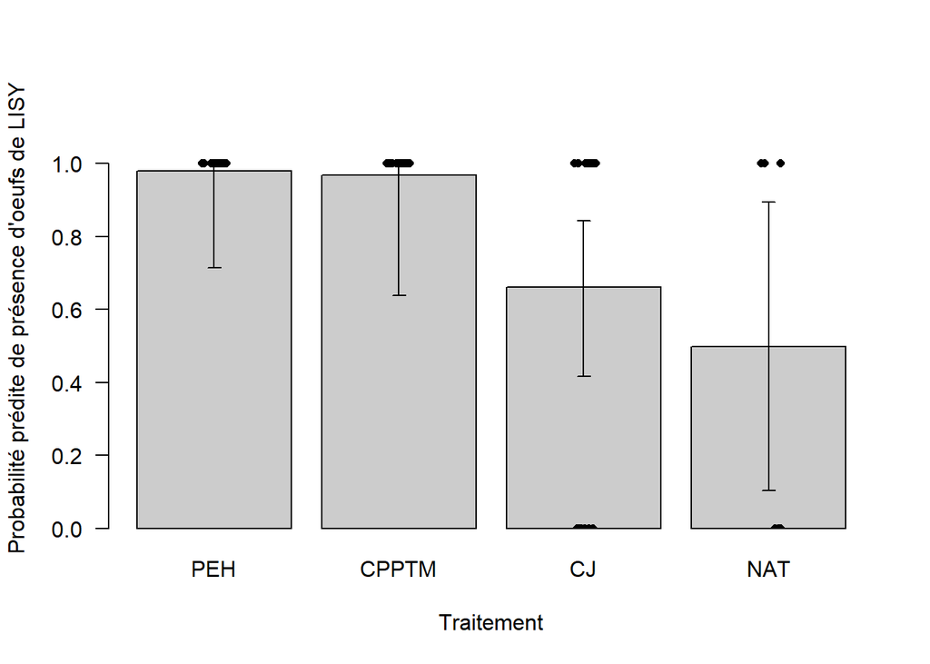

   ```r
   emm_prob <- emmeans(mod1, ~ Traitement, type = "response")
   res <- as.data.frame(emm_prob)
   ordre <- c("PEH", "CPPTM", "CJ", "NAT")
   res <- res[match(ordre, res$Traitement), ]
   moyennes <- res$prob
   inf <- res$asymp.LCL
   sup <- res$asymp.UCL
   jit <- jitter(barres[match(df$Traitement, res$Traitement)],amount = 0.08)

   barres <- barplot(moyennes,
                     names.arg = res$Traitement,
                     ylim = c(0, 1.15),
                     ylab = "Probabilité prédite de présence d'oeufs de LISY",
                     xlab = "Traitement",
                     col = "grey80",
                     border = "black",
                     las = 1)
   set.seed(123)
   points(jit, df$pres,
          pch = 16,
          cex = 0.8,
          col = "black")
   arrows(x0 = barres, y0 = inf,
          x1 = barres, y1 = sup,
          angle = 90, code = 3, length = 0.05)
   ```

   n PEH = 16 , n CPPTM = 15, n CJ = 19, NAT = 6

   Ici, je n’ai pas mis de lettres mais à prendre en note que le summary suggère que PEH varierait significativement comparé au CJ et NAT.  
   Il semble avoir moins de présence d’oeufs quand le couvert forestier est fermé.

## Est-ce que la densité des oeufs (effort reproductif) varie selon le type de traitement?

Ici, l’effort de reproduction est représenté par le nombre d’oeufs pondus/m2 dans chaque étangs. Plus la densité d’oeufs est élevée, plus l’effort de reproduction a été grand. La superficie choisi des étangs est la superficie maximum, soit la superficie correspondant à la période de ponte

### Ambystome :

1. **Préparation des données**

   ```r
   df <-read_excel("C:/Users/super/Université du Québec en Outaouais/CLAUDIE ÉTANGS VERNAUX - Documents/Stats/Reproduction/Oeufs/Data_base_oeufs.xlsx", sheet = 1)
   df$Traitement <- factor(df$Traitement)
   df <- subset(df, Amby != 0) #retire tout les étangs qui n'ont pas d'oeufs
   table(df$Traitement)
   ```

   ```
      CJ CPPTM   NAT   PEH
      14     6     6     2
   ```

```r
df2 <- df[df$Traitement != "PEH", ]
df2$Traitement <- droplevels(df2$Traitement) #retire le niveau de ''PEH''
df2$Traitement <- relevel(df2$Traitement, ref = "CPPTM") #Le traitement le plus similaire à PEH c'est CPPTM
table(df2$Traitement)
```

```
CPPTM    CJ   NAT
    6    14     6
```

```r
df2
```

```
# A tibble: 26 × 15
   No_etang  Traitement Superficie_m2  Amby  ANAM anoure  DRVE  LICA  LICL  LISE
   <chr>     <fct>              <dbl> <dbl> <dbl>  <dbl> <dbl> <dbl> <dbl> <dbl>
 1 1WATCJ6   CJ                 16.5      1     0      0     0     0     0     0
 2 2WATCJ5   CJ                 43.5      3     0      0     0     0     0     0
 3 3WATCJ1   CJ                  2.66    16     0      0     0     0     0     0
 4 4WATCJ2   CJ                 38.1      6     0      0     0     0     0     0
 5 5WATCJ4   CJ                  7.2      3     0      0     0     0     0     0
 6 6WATCJ3   CJ                 24       10     0      0     0     0     0     0
 7 10WATCPP… CPPTM              16.9      1     0      0     0     0     0     0
 8 58WATCPP… CPPTM              16.3      1     0      0     0     0     0     0
 9 24DORCJ11 CJ                  3.42     1     0      0     0     0     0     0
10 25DORCJ12 CJ                 49.7     10     0      0     0     0     0     0
# ℹ 16 more rows
# ℹ 5 more variables: LISY <dbl>, NOVI <dbl>, PSCR <dbl>, X <dbl>, Y <dbl>
```

Avec le tableau, on peut voir que les n sont bas. Dans ce cas, il sera difficile de faire un beau modèle. On va donc passer directement à la visualisation.

2. **Visualisation:**

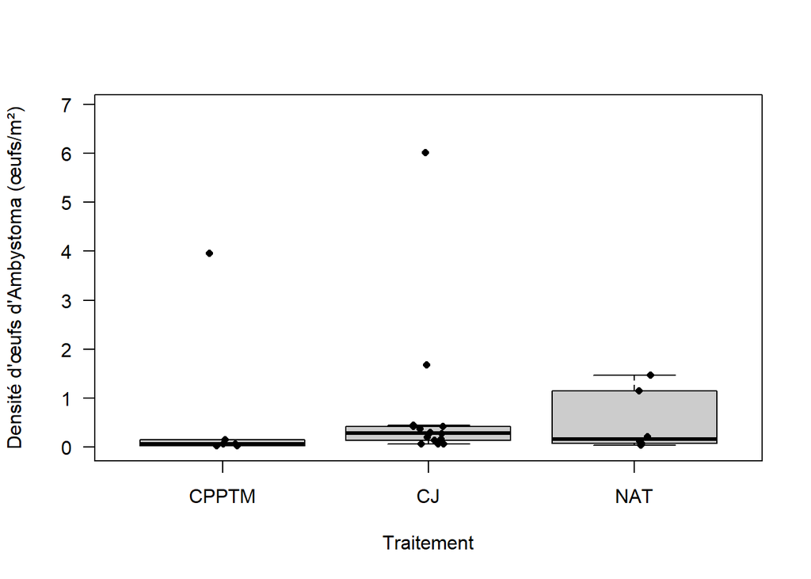

   ```r
   ordre <- c("CPPTM", "CJ", "NAT")
   df2$Densite_Amby <- df2$Amby / df2$Superficie_m2
   jit <- jitter(as.numeric(df2$Traitement), amount = 0.08)
   df2$Traitement <- factor(df2$Traitement, levels = ordre)

   boxplot(Densite_Amby ~ Traitement,
           data = df2,
           ylim = c(0, max(df2$Densite_Amby, na.rm = TRUE) * 1.15),
           ylab = "Densité d'œufs d'Ambystoma (œufs/m²)",
           xlab = "Traitement",
           col = "grey80",
           border = "black",
           las = 1,
           outline = FALSE)
   set.seed(123)
   points(jit,
          df2$Densite_Amby,
          pch = 16,
          cex = 0.8,
          col = "black")
   ```

n CPPTM = 6, n CJ = 14, NAT = 6

En effet, rien semble significatif, on ne passera pas à d’autres analyses.

### LISY :

1. **Préparation des données :**

   ```r
   df <-read_excel("C:/Users/super/Université du Québec en Outaouais/CLAUDIE ÉTANGS VERNAUX - Documents/Stats/Reproduction/Oeufs/Data_base_oeufs.xlsx", sheet = 1)
   df$Traitement <- factor(df$Traitement)
   df$X <- as.numeric(scale(df$X))
   df$Y <- as.numeric(scale(df$Y)) #La standardisation permet au modèle de mieux fonctionner tout en conservant la relation spatiale parce que l'ordre de grandeur des x et y était originalement trop grand
   df <- subset(df, LISY != 0) #retire tout les étangs qui n'ont pas d'oeufs
   df$Traitement <- relevel(df$Traitement, ref = "PEH") #S'assurer que PEH est la référence
   table(df$Traitement) #NAT est très bas.
   ```

   ```
     PEH    CJ CPPTM   NAT
      16    13    15     3
   ```

   Ici, le NAT est anecdotique (n=3) donc va falloir le retirer.

   ```r
   df2 <- df[df$Traitement != "NAT", ]
   df2$Traitement <- droplevels(df2$Traitement) #retire le niveau de ''NAT''
   table(df2$Traitement)
   ```

   ```
     PEH    CJ CPPTM
      16    13    15
   ```

   ```r
   df2
   ```

   ```
   # A tibble: 44 × 15
      No_etang  Traitement Superficie_m2  Amby  ANAM anoure  DRVE  LICA  LICL  LISE
      <chr>     <fct>              <dbl> <dbl> <dbl>  <dbl> <dbl> <dbl> <dbl> <dbl>
    1 2WATCJ5   CJ                 43.5      3     0      0     0     0     0     0
    2 5WATCJ4   CJ                  7.2      3     0      0     0     0     0     0
    3 6WATCJ3   CJ                 24       10     0      0     0     0     0     0
    4 17WATPEH… PEH                 6.21     0     0      0     0     0     0     0
    5 7WATPEH2  PEH                26.7      0     0      0     0     0     0     0
    6 12WATPEH5 PEH                57.4      0     0      0     0     0     0     0
    7 8WATPEH1  PEH                13.4      0     0      0     0     0     0     0
    8 9WATPEH6  PEH                13.3      0     0      0     0     0     0     0
    9 13WATPEH8 PEH                12.0      0     0      0     0     0     0     0
   10 14WATPEH8 PEH                 8.80     0     0      0     0     0     0     0
   # ℹ 34 more rows
   # ℹ 5 more variables: LISY <dbl>, NOVI <dbl>, PSCR <dbl>, X <dbl>, Y <dbl>
   ```

   Ici, les n sont un peu plus élevés. Un modèle sera alors créé pour voir si quelque chose est significatif
2. **Choix du modèle**

   Ici, un modèle linéaire est intéressant. J’ai des données de comptage avec beaucoup de variation. De plus, je n’ai pas de zéros, alors il faut choisir une famille adaptée à cette condition. Je vais aller pour un glmm avec la famille truncated_nbinom:

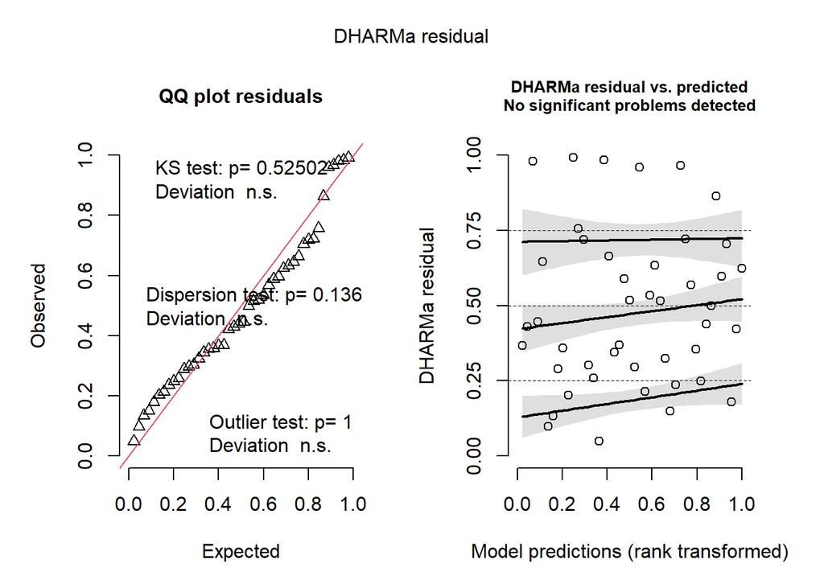

   ```r
   library(glmmTMB)
   mod1 <- glmmTMB(LISY ~ Traitement + X + Y + offset(log(Superficie_m2)),family = truncated_nbinom2(link = "log"),data = df2)
   res <- simulateResiduals(mod1)
   plot(res) #ok
   ```

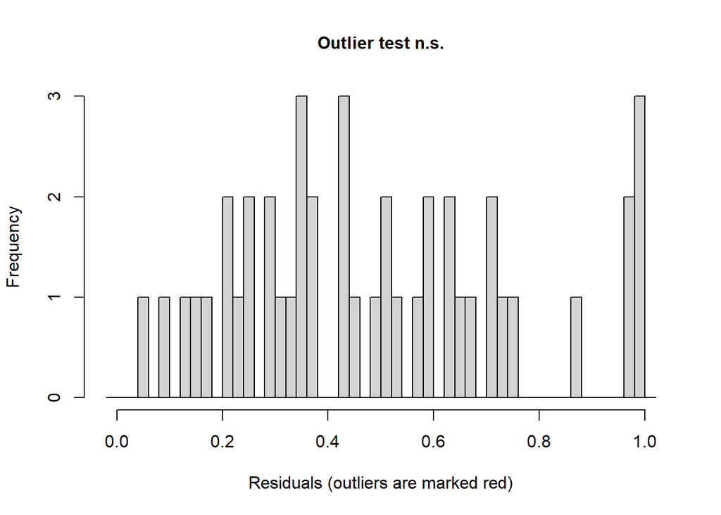

   ```
       DHARMa bootstrapped outlier test

   data:  res
   outliers at both margin(s) = 0, observations = 44, p-value = 1
   alternative hypothesis: two.sided
    percent confidence interval:
    0.00000000 0.02272727
   sample estimates:
   outlier frequency (expected: 0.00636363636363636 )
                                                    0
   ```

   ```r
   testOutliers(res)#ok
   ```

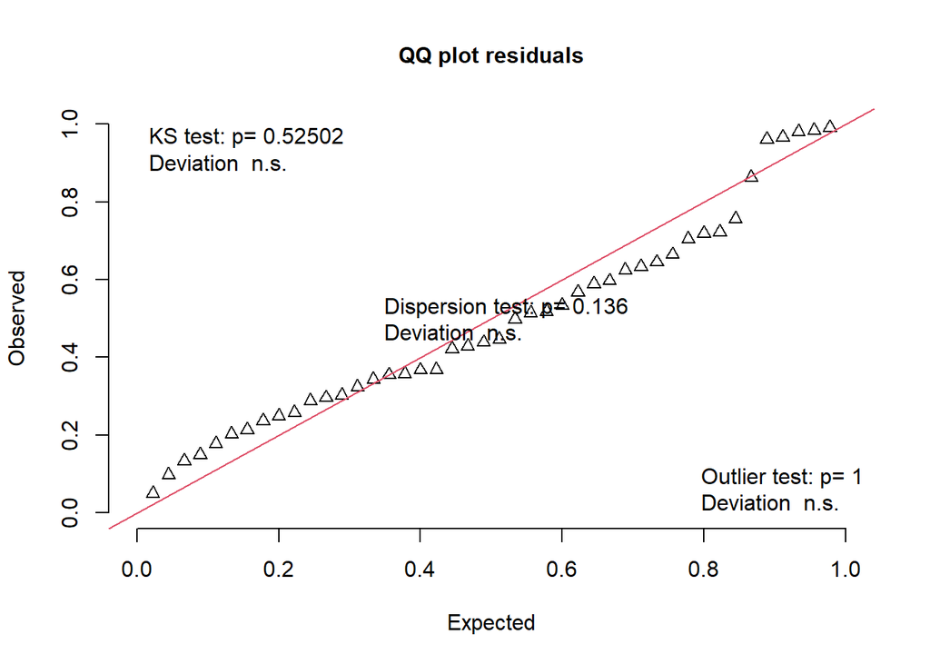

   ```
       Exact one-sample Kolmogorov-Smirnov test

   data:  simulationOutput$scaledResiduals
   D = 0.1188, p-value = 0.525
   alternative hypothesis: two-sided
   ```

   ```r
   testUniformity(res) #ok
   ```

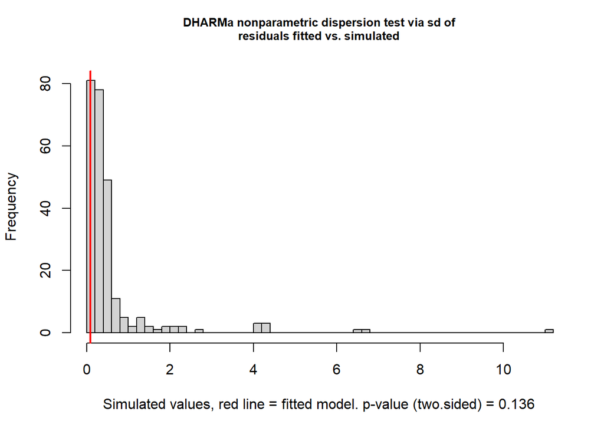

   ```
       DHARMa nonparametric dispersion test via sd of residuals fitted vs.
       simulated

   data:  simulationOutput
   dispersion = 0.14971, p-value = 0.136
   alternative hypothesis: two.sided
   ```

   ```r
   testDispersion(res) #ok
   ```

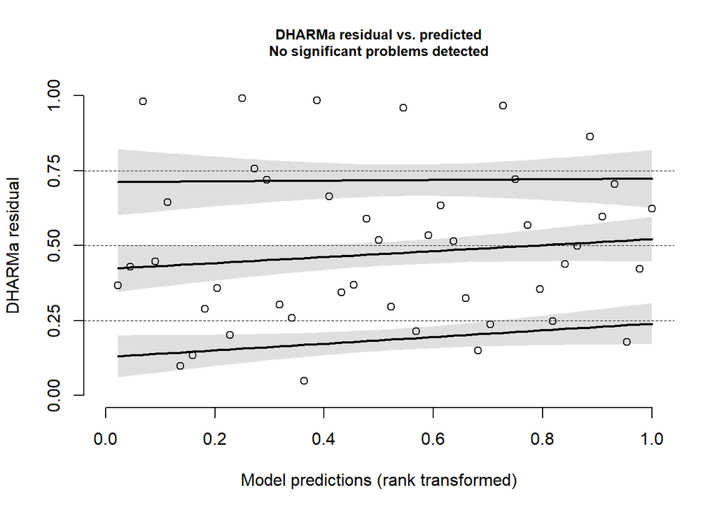

   ```
       Test for location of quantiles via qgam

   data:  res
   p-value = 0.3929
   alternative hypothesis: both
   ```

   ```r
   testQuantiles(res) #ok
   ```

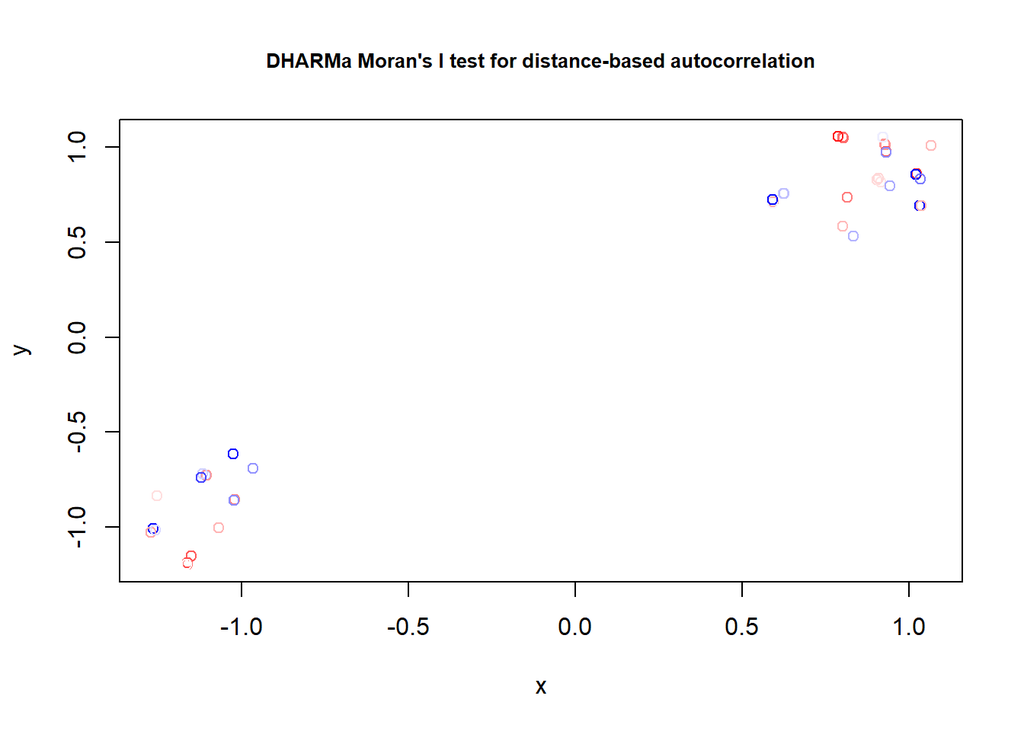

   ```
       DHARMa Moran's I test for distance-based autocorrelation

   data:  res
   observed = -0.057571, expected = -0.023256, sd = 0.110725, p-value =
   0.7566
   alternative hypothesis: Distance-based autocorrelation
   ```

   ```r
   testSpatialAutocorrelation(res,x = df2$X,y = df2$Y) #ok
   ```

3. **Analyse:**

   ```r
   summary(mod1)
   ```

   ```
    Family: truncated_nbinom2  ( log )
   Formula:          LISY ~ Traitement + X + Y + offset(log(Superficie_m2))
   Data: df2

         AIC       BIC    logLik -2*log(L)  df.resid
       232.5     243.2    -110.2     220.5        38


   Dispersion parameter for truncated_nbinom2 family (): 0.859

   Conditional model:
                   Estimate Std. Error z value Pr(>|z|)
   (Intercept)      -1.5884     0.3450  -4.604 4.14e-06 ***
   TraitementCJ      0.1718     0.4658   0.369   0.7123
   TraitementCPPTM   0.9135     0.4840   1.887   0.0591 .
   X                -0.0375     1.1496  -0.033   0.9740
   Y                -0.3016     1.3913  -0.217   0.8284
   ---
   Signif. codes:  0 '***' 0.001 '**' 0.01 '*' 0.05 '.' 0.1 ' ' 1
   ```

   Rien n’est significatif ici.
4. **Visualisation :**

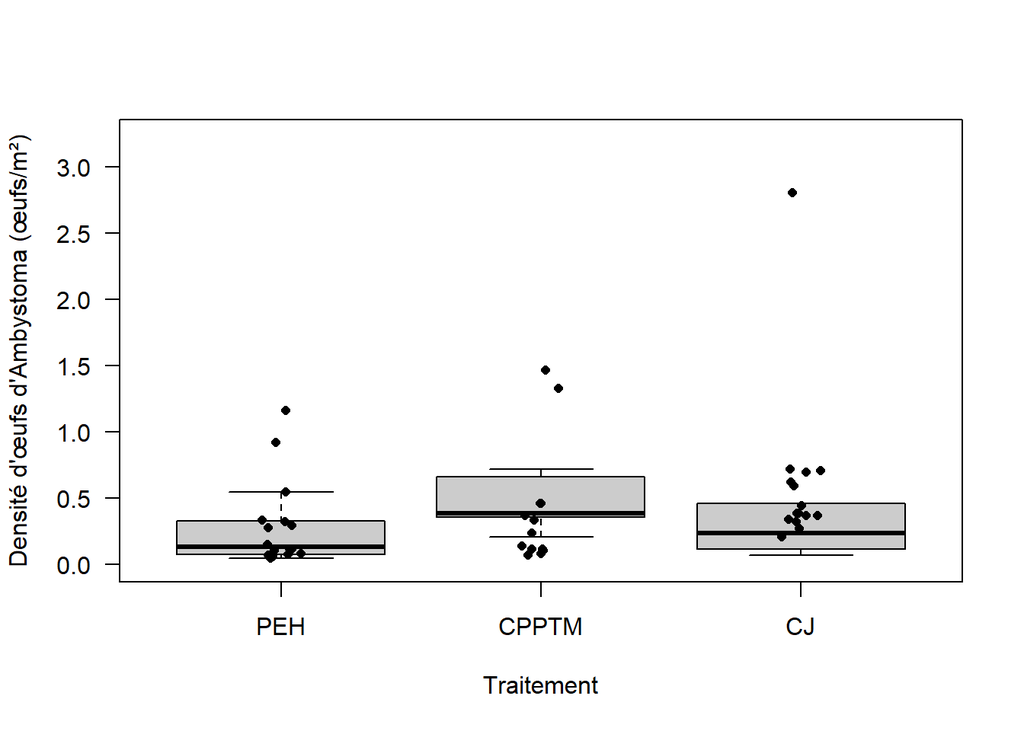

```r
ordre <- c("PEH", "CPPTM", "CJ")
jit <- jitter(as.numeric(df2$Traitement), amount = 0.08)
df2$Traitement <- factor(df2$Traitement, levels = ordre)
df2$Densite_LISY <- df2$LISY / df2$Superficie_m2

boxplot(Densite_LISY ~ Traitement,
        data = df2,
        ylim = c(0, max(df2$Densite_LISY, na.rm = TRUE) * 1.15),
        ylab = "Densité d'œufs d'Ambystoma (œufs/m²)",
        xlab = "Traitement",
        col = "grey80",
        border = "black",
        las = 1,
        outline = FALSE)
set.seed(123)
points(jit,
       df2$Densite_LISY,
       pch = 16,
       cex = 0.8,
       col = "black")
```

n PEH = 16 , n CPPTM = 15, n CJ = 13

Pas trop de tendance visible.

## Est-ce que la présence de larve varie selon le type de traitement ?

### Ambystome :

1. **Préparation des données :**

   ```r
   df <-read_excel("C:/Users/super/Université du Québec en Outaouais/CLAUDIE ÉTANGS VERNAUX - Documents/Stats/Reproduction/Larves/Bio_DataBase_tetard.xlsx", sheet = 1)
   df$Traitement <- factor(df$Traitement)
   df$X <- as.numeric(scale(df$X))
   df$Y <- as.numeric(scale(df$Y)) #La standardisation permet au modèle de mieux fonctionner tout en conservant la relation spatiale parce que l'ordre de grandeur des x et y était originalement trop grand
   df$pres <- ifelse(df$amby > 0, 1, 0) #création d'une colone de présence-abscence
   df$Traitement <- relevel(df$Traitement, ref = "PEH") #S'assurer que PEH est la référence
   df
   ```

   ```
   # A tibble: 57 × 15
      No_etang   Traitement  ANAM  amby anoure  DRVE  LICA  LICL  LISE  LISY  NOVI
      <chr>      <fct>      <dbl> <dbl>  <dbl> <dbl> <dbl> <dbl> <dbl> <dbl> <dbl>
    1 1WATCJ6    CJ             0     0      0     0     0     0     0   0       0
    2 2WATCJ5    CJ             0     0      0     0     0     0     0   0       0
    3 3WATCJ1    CJ             0     0      0     0     0     0     0   0       0
    4 4WATCJ2    CJ             0    20      0     0     0     0     0   0       0
    5 5WATCJ4    CJ             0    14      0     0     0     0     0  16       0
    6 6WATCJ3    CJ             0    11      0     0     0     0     0  12       0
    7 17WATPEH10 PEH            0     0      0     0     0     0     0   0       0
    8 7WATPEH2   PEH            0     0      0     0     0     0     0  16.8     0
    9 12WATPEH5  PEH            0     0      0     0     0     0     0  20       0
   10 8WATPEH1   PEH            0     0      0     0     0     0     0  15       0
   # ℹ 47 more rows
   # ℹ 4 more variables: PSCR <dbl>, X <dbl>, Y <dbl>, pres <dbl>
   ```

   ```r
   df_larvesA <- df
   ```

2. **Choix du modèle :**

   Ici, un glm binaire serait intéressant.

   ```r
   table(df$Traitement, df$pres)
   ```

   ```
            0  1
     PEH   16  1
     CJ    11  8
     CPPTM 11  4
     NAT    3  3
   ```

Pour PEH, on voit une séparation quasi-complète (16 absent et 1 présent). Une correction devra donc être appliquée pour le bon fonctionnement du modèle (brglmFit)

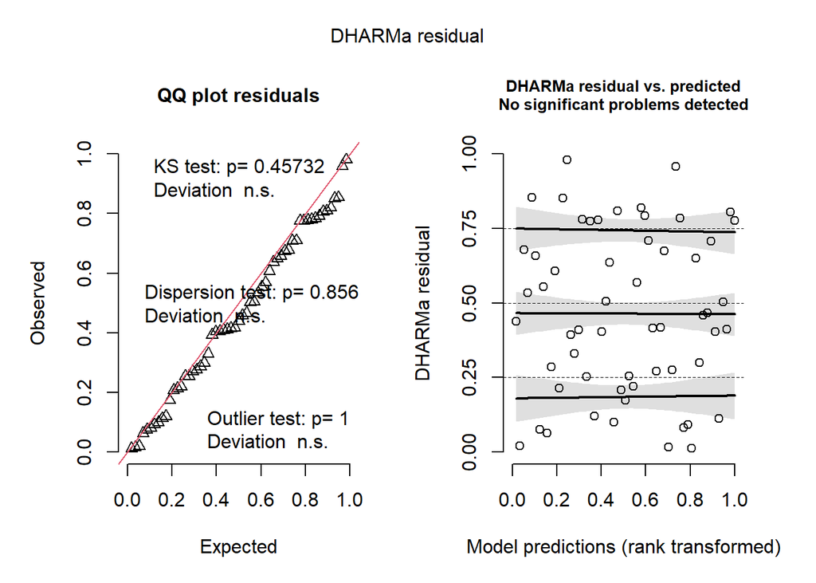

```r
library(brglm2)
mod1 <- glm(pres ~ Traitement + X + Y,family = binomial(link = "logit"),data = df,method = brglmFit)
mod1A <- mod1
res1 <- simulateResiduals(mod1)
plot(res1) #C'est beau :)
```

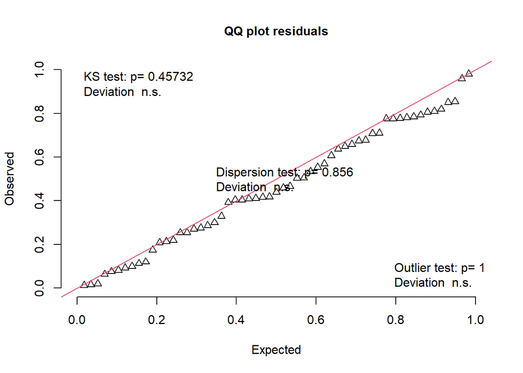

```
    Exact one-sample Kolmogorov-Smirnov test

data:  simulationOutput$scaledResiduals
D = 0.11048, p-value = 0.4573
alternative hypothesis: two-sided
```

```r
testUniformity(res1) #ok
```

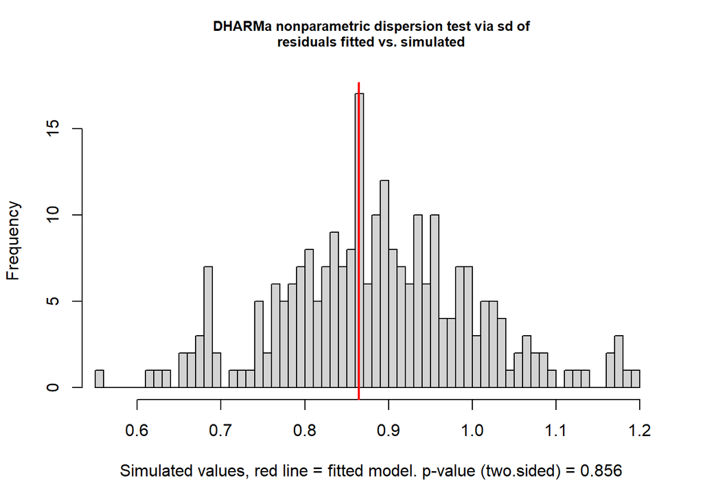

```
    DHARMa nonparametric dispersion test via sd of residuals fitted vs.
    simulated

data:  simulationOutput
dispersion = 0.97501, p-value = 0.856
alternative hypothesis: two.sided
```

```r
testDispersion(res1) #ok
```

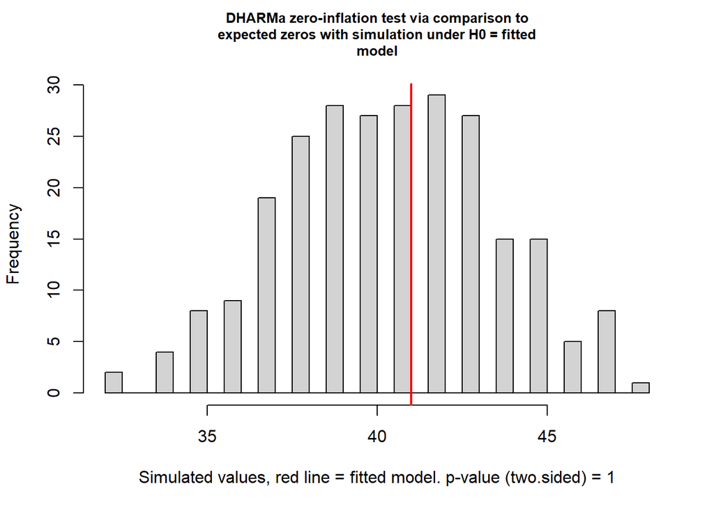

```
    DHARMa zero-inflation test via comparison to expected zeros with
    simulation under H0 = fitted model

data:  simulationOutput
ratioObsSim = 1.0103, p-value = 1
alternative hypothesis: two.sided
```

```r
testZeroInflation(res1) #ok
```

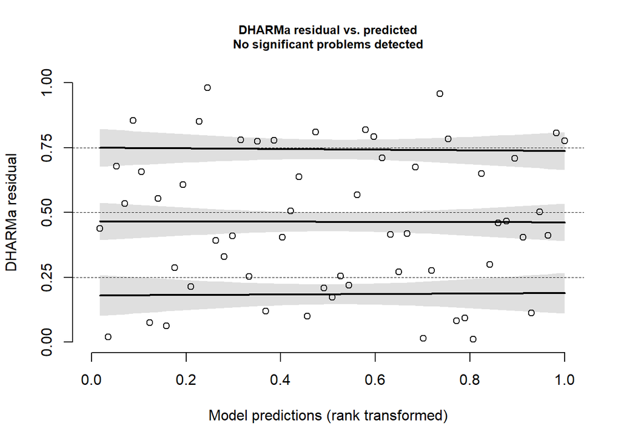

```
    Test for location of quantiles via qgam

data:  res
p-value = 0.5474
alternative hypothesis: both
```

```r
testQuantiles(res1) #ok
```

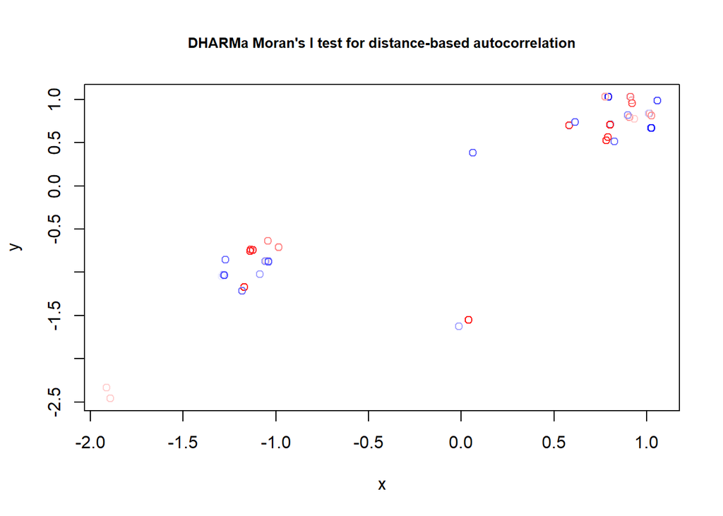

```
    DHARMa Moran's I test for distance-based autocorrelation

data:  res1
observed = 0.055716, expected = -0.017857, sd = 0.095827, p-value =
0.4426
alternative hypothesis: Distance-based autocorrelation
```

```r
testSpatialAutocorrelation(res1,x = df$X,y = df$Y) #ok
```

Les résultats sont beau, le modèle est bien représentatif.

3. **Analyse**

   ```r
   summary(mod1)
   ```

   ```
   Call:
   glm(formula = pres ~ Traitement + X + Y, family = binomial(link = "logit"),
       data = df, method = brglmFit)

   Deviance Residuals:
       Min       1Q   Median       3Q      Max
   -1.1198  -0.8623  -0.4506   0.9854   2.1270

   Coefficients:
                   Estimate Std. Error z value Pr(>|z|)
   (Intercept)      -2.3709     0.8654  -2.740  0.00615 **
   TraitementCJ      2.0472     0.9834   2.082  0.03737 *
   TraitementCPPTM   1.3828     1.0380   1.332  0.18282
   TraitementNAT     2.6996     1.4280   1.890  0.05869 .
   X                -0.2583     0.8933  -0.289  0.77244
   Y                 0.4116     0.9542   0.431  0.66617
   ---
   Signif. codes:  0 '***' 0.001 '**' 0.01 '*' 0.05 '.' 0.1 ' ' 1

   (Dispersion parameter for binomial family taken to be 1)

       Null deviance: 67.676  on 56  degrees of freedom
   Residual deviance: 58.980  on 51  degrees of freedom
   AIC:  70.98

   Type of estimator: AS_mixed (mixed bias-reducing adjusted score equations)
   Number of Fisher Scoring iterations: 11
   ```

PEH-CJ sont significatif, à voir avec l’inflation du p-value causé par la correction Tukey dans emmeans

```r
emm <- emmeans(mod1, ~ Traitement)
emm
```

```
 Traitement emmean    SE  df asymp.LCL asymp.UCL
 PEH        -2.371 0.865 Inf     -4.07    -0.675
 CJ         -0.324 0.469 Inf     -1.24     0.596
 CPPTM      -0.988 0.591 Inf     -2.15     0.170
 NAT         0.329 1.070 Inf     -1.77     2.432

Results are given on the logit (not the response) scale.
Confidence level used: 0.95
```

```r
pairs(emm)
```

```
 contrast    estimate    SE  df z.ratio p.value
 PEH - CJ      -2.047 0.983 Inf  -2.082  0.1590
 PEH - CPPTM   -1.383 1.040 Inf  -1.332  0.5424
 PEH - NAT     -2.700 1.430 Inf  -1.890  0.2321
 CJ - CPPTM     0.664 0.742 Inf   0.895  0.8075
 CJ - NAT      -0.652 1.200 Inf  -0.545  0.9479
 CPPTM - NAT   -1.317 1.300 Inf  -1.015  0.7409

Results are given on the log odds ratio (not the response) scale.
P value adjustment: tukey method for comparing a family of 4 estimates
```

Avec la correction de Tukey, rien ne sort comme significatif.

4. **Visualisation :**

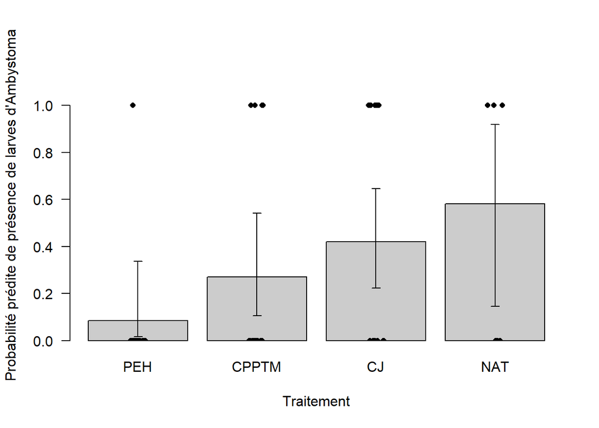

   ```r
   emm_prob <- emmeans(mod1, ~ Traitement, type = "response")
   res <- as.data.frame(emm_prob)
   ordre <- c("PEH", "CPPTM", "CJ", "NAT")
   res <- res[match(ordre, res$Traitement), ]
   moyennes <- res$prob
   inf <- res$asymp.LCL
   sup <- res$asymp.UCL
   jit <- jitter(barres[match(df$Traitement, res$Traitement)],amount = 0.08)

   barres <- barplot(moyennes,
                     names.arg = res$Traitement,
                     ylim = c(0, 1.15),
                     ylab = "Probabilité prédite de présence de larves d'Ambystoma",
                     xlab = "Traitement",
                     col = "grey80",
                     border = "black",
                     las = 1)
   set.seed(123)
   points(jit, df$pres,
          pch = 16,
          cex = 0.8,
          col = "black")
   arrows(x0 = barres, y0 = inf,
          x1 = barres, y1 = sup,
          angle = 90, code = 3, length = 0.05)
   ```

n PEH = 17 , n CPPTM = 15, n CJ = 19, NAT = 6

À noter que selon le summary, PEH serait différent comparé au CJ

### LISY :

1. **Préparation des données :**

   ```r
   df <-read_excel("C:/Users/super/Université du Québec en Outaouais/CLAUDIE ÉTANGS VERNAUX - Documents/Stats/Reproduction/Larves/Bio_DataBase_tetard.xlsx", sheet = 1)
   df$X <- as.numeric(scale(df$X))
   df$Y <- as.numeric(scale(df$Y))
   df$pres <- ifelse(df$LISY > 0, 1, 0) #création d'une colone de présence-abscence
   df$Traitement <- factor(df$Traitement)
   df$Traitement <- relevel(df$Traitement, ref = "PEH") #S'assurer que PEH est la référence
   df
   ```

   ```
   # A tibble: 57 × 15
      No_etang   Traitement  ANAM  amby anoure  DRVE  LICA  LICL  LISE  LISY  NOVI
      <chr>      <fct>      <dbl> <dbl>  <dbl> <dbl> <dbl> <dbl> <dbl> <dbl> <dbl>
    1 1WATCJ6    CJ             0     0      0     0     0     0     0   0       0
    2 2WATCJ5    CJ             0     0      0     0     0     0     0   0       0
    3 3WATCJ1    CJ             0     0      0     0     0     0     0   0       0
    4 4WATCJ2    CJ             0    20      0     0     0     0     0   0       0
    5 5WATCJ4    CJ             0    14      0     0     0     0     0  16       0
    6 6WATCJ3    CJ             0    11      0     0     0     0     0  12       0
    7 17WATPEH10 PEH            0     0      0     0     0     0     0   0       0
    8 7WATPEH2   PEH            0     0      0     0     0     0     0  16.8     0
    9 12WATPEH5  PEH            0     0      0     0     0     0     0  20       0
   10 8WATPEH1   PEH            0     0      0     0     0     0     0  15       0
   # ℹ 47 more rows
   # ℹ 4 more variables: PSCR <dbl>, X <dbl>, Y <dbl>, pres <dbl>
   ```

   ```r
   df_larvesL <- df
   ```

2. **Choix du modèle** :

   Encore une fois, un glm binaire serait intéressant

   ```r
   table(df$Traitement, df$pres)
   ```

   ```
            0  1
     PEH    7 10
     CJ    11  8
     CPPTM 10  5
     NAT    2  4
   ```

   Ici, il n’y a pas de séparation, donc pas besoin de correction

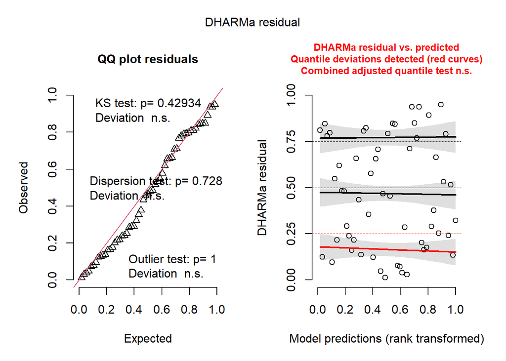

   ```r
   mod1 <- glm(pres ~ Traitement + X + Y,family = binomial(link = "logit"),data = df)
   mod1L <- mod1
   res1 <- simulateResiduals(mod1)
   plot(res1) #res vs pred ligne rouge au dernier graph
   ```

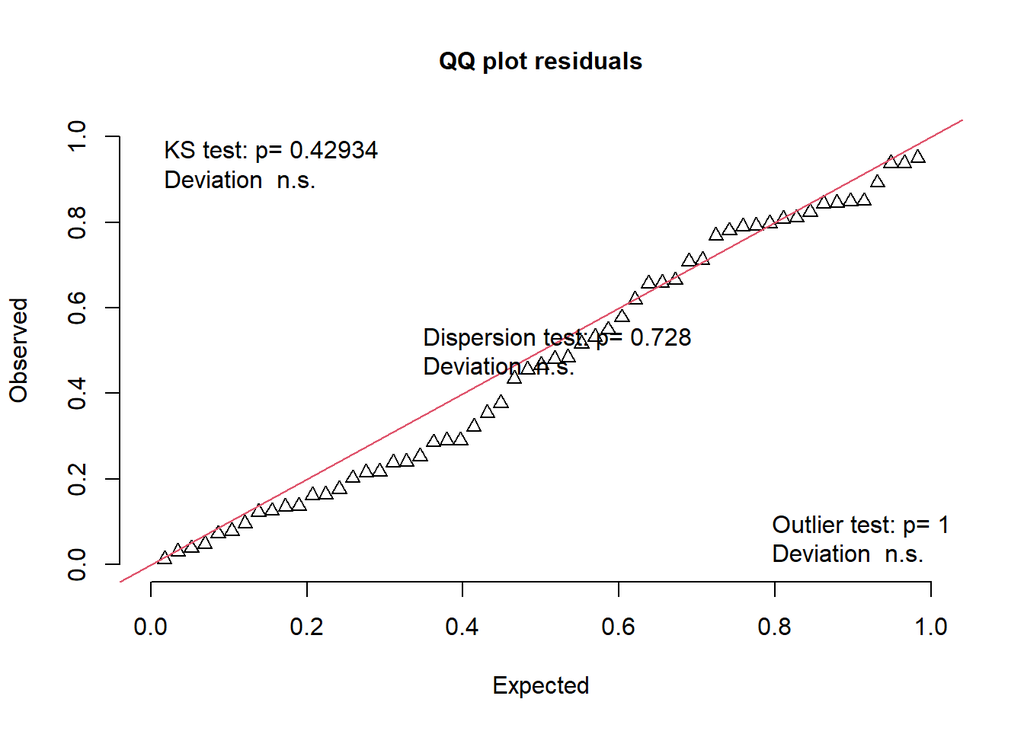

   ```
       Exact one-sample Kolmogorov-Smirnov test

   data:  simulationOutput$scaledResiduals
   D = 0.11297, p-value = 0.4293
   alternative hypothesis: two-sided
   ```

   ```r
   testUniformity(res1) #ok
   ```